# Jupyter Notebook Viewer

```python
import time
begin = time.time()
```

```python
os.environ["SAGE_NUM_THREADS"] = '10'
```

```python
from lefschetz_family import Hypersurface

import logging
logging.basicConfig()
logging.getLogger('lefschetz_family.hypersurface').setLevel(logging.INFO)
```

```python
S.<X,Y,Z,W> =PolynomialRing(QQ)
```

We will compute the homology of this polynomial

```python
P = X^4+Y^4+Z^4+W^4
show(P)
```

\[\newcommand{\Bold}[1]{\mathbf{#1}}X^{4} + Y^{4} + Z^{4} + W^{4}\]

```python
fibration = [vector([0, 0, 0, 1]), vector([2, 3, 1, 0]), vector([7, -10, -4, -8])]
```

```python
surface = Hypersurface(P, fibration=fibration, method="voronoi", nbits=1000)
```

```
INFO:lefschetz_family.hypersurface:[2] Computing fundamental group with 36 critical values.
INFO:lefschetz_family.hypersurface:[2] Fundamental group computed in 00:00:05.
```

We need to have an effective period matrix of the fiber. We care about the basis of cohomology in which this matrix is given, but not about the basis of homology (although we have it explicitely).

```python
surface.fiber.cohomology
```

```
INFO:lefschetz_family.hypersurface:[1] Computing fundamental group with 12 critical values.
INFO:lefschetz_family.hypersurface:[1] Fundamental group computed in 00:00:01.
```

```
[Z, Y, X, Z^5, Y*Z^4, X*Z^4]
```

```python
show(surface.fiber.period_matrix)
surface.fiber.period_matrix.dimensions()
```

```
INFO:lefschetz_family.hypersurface:[1] Computing Picard-Fuchs equations of 6 forms in dimension 1
INFO:lefschetz_family.hypersurface:[1] Operator [1/6] has order 3 and degree 30 for form with numerator of degree 1
INFO:lefschetz_family.hypersurface:[1] Operator [2/6] has order 3 and degree 30 for form with numerator of degree 1
INFO:lefschetz_family.hypersurface:[1] Operator [3/6] has order 3 and degree 30 for form with numerator of degree 1
INFO:lefschetz_family.hypersurface:[1] Operator [4/6] has order 3 and degree 74 for form with numerator of degree 5
INFO:lefschetz_family.hypersurface:[1] Operator [5/6] has order 3 and degree 78 for form with numerator of degree 5
INFO:lefschetz_family.hypersurface:[1] Operator [6/6] has order 3 and degree 78 for form with numerator of degree 5
INFO:lefschetz_family.hypersurface:[1] Computing numerical transition matrices of operator of order 4 and degree 30 (48 edges total).
INFO:lefschetz_family.hypersurface:[1] Integration finished -- total time: 00:00:14.
INFO:lefschetz_family.hypersurface:[1] Reconstructed homology from monodromy -- total time: 00:00:00.
INFO:lefschetz_family.hypersurface:[1] Computing numerical transition matrices of operator of order 4 and degree 30 (48 edges total).
INFO:lefschetz_family.hypersurface:[1] Integration finished -- total time: 00:00:14.
INFO:lefschetz_family.hypersurface:[1] Computing numerical transition matrices of operator of order 4 and degree 30 (48 edges total).
INFO:lefschetz_family.hypersurface:[1] Integration finished -- total time: 00:00:13.
INFO:lefschetz_family.hypersurface:[1] Computing numerical transition matrices of operator of order 4 and degree 74 (48 edges total).
INFO:lefschetz_family.hypersurface:[1] Integration finished -- total time: 00:01:43.
INFO:lefschetz_family.hypersurface:[1] Computing numerical transition matrices of operator of order 4 and degree 78 (48 edges total).
INFO:lefschetz_family.hypersurface:[1] Integration finished -- total time: 00:02:06.
INFO:lefschetz_family.hypersurface:[1] Computing numerical transition matrices of operator of order 4 and degree 78 (48 edges total).
INFO:lefschetz_family.hypersurface:[1] Integration finished -- total time: 00:02:05.
```

\[\newcommand{\Bold}[1]{\mathbf{#1}}\left(\begin{array}{rrrrrr} \verb|[0.230799375630032042425209752230097346804603195495972110116731…|\verb| |\verb|+/-|\verb| |\verb|6.15e-291]|\verb| |\verb|+|\verb| |\verb|[+/-|\verb| |\verb|1.44e-291]*I| & \verb|[-0.009204625958990722985549499917646556959502208684884513063082…|\verb| |\verb|+/-|\verb| |\verb|6.27e-289]|\verb| |\verb|+|\verb| |\verb|[0.015648638385260768662060101958363952566964123811393851989998…|\verb| |\verb|+/-|\verb| |\verb|7.28e-289]*I| & \verb|[0.240004001589022765410759252147743903764105404180856623179814…|\verb| |\verb|+/-|\verb| |\verb|6.12e-287]|\verb| |\verb|+|\verb| |\verb|[0.015648638385260768662060101958363952566964123811393851989998…|\verb| |\verb|+/-|\verb| |\verb|8.32e-287]*I| & \verb|[0.240378365122357429445142179249024030602842209834619384366620…|\verb| |\verb|+/-|\verb| |\verb|1.63e-289]|\verb| |\verb|+|\verb| |\verb|[0.238644300681607586884283615640662632349162377519665892292822…|\verb| |\verb|+/-|\verb| |\verb|5.61e-289]*I| & \verb|[+/-|\verb| |\verb|3.88e-288]|\verb| |\verb|+|\verb| |\verb|[0.012119387093703095396736346478543327397010628307848844978199…|\verb| |\verb|+/-|\verb| |\verb|4.73e-288]*I| & \verb|[0.239629638055688101376376325046463776925368598527093861993008…|\verb| |\verb|+/-|\verb| |\verb|7.21e-285]|\verb| |\verb|+|\verb| |\verb|[0.238644300681607586884283615640662632349162377519665892292822…|\verb| |\verb|+/-|\verb| |\verb|4.59e-285]*I| \\ \verb|[0.138982092181914207537945327700568433033928390780038282346442…|\verb| |\verb|+/-|\verb| |\verb|1.66e-291]|\verb| |\verb|+|\verb| |\verb|[+/-|\verb| |\verb|1.19e-291]*I| & \verb|[0.210223053595825316369432970222079640266006077634922649099814…|\verb| |\verb|+/-|\verb| |\verb|7.00e-291]|\verb| |\verb|+|\verb| |\verb|[0.195349116257485273313508559985099322345217821214297843946282…|\verb| |\verb|+/-|\verb| |\verb|7.45e-291]*I| & \verb|[-0.071240961413911108831487642521511207232077686854884366753372…|\verb| |\verb|+/-|\verb| |\verb|3.32e-288]|\verb| |\verb|+|\verb| |\verb|[0.195349116257485273313508559985099322345217821214297843946282…|\verb| |\verb|+/-|\verb| |\verb|3.42e-288]*I| & \verb|[0.079573912500377978106853898004889581810089607951705373846749…|\verb| |\verb|+/-|\verb| |\verb|6.06e-291]|\verb| |\verb|+|\verb| |\verb|[0.087248172140423089230377016990373761402050552159196157528233…|\verb| |\verb|+/-|\verb| |\verb|3.58e-291]*I| & \verb|[+/-|\verb| |\verb|2.25e-290]|\verb| |\verb|+|\verb| |\verb|[0.296931661549907455050691584114280086472073202631097004991687…|\verb| |\verb|+/-|\verb| |\verb|4.33e-290]*I| & \verb|[-0.222055835328200195769829183047911996274244981661474107353494…|\verb| |\verb|+/-|\verb| |\verb|3.40e-288]|\verb| |\verb|+|\verb| |\verb|[0.087248172140423089230377016990373761402050552159196157528233…|\verb| |\verb|+/-|\verb| |\verb|3.00e-288]*I| \\ \verb|[-0.230085698738089442141027908123347115728210453941345877146655…|\verb| |\verb|+/-|\verb| |\verb|2.58e-291]|\verb| |\verb|+|\verb| |\verb|[+/-|\verb| |\…

```
(6, 6)
```

For each critical point we compute a simple loop around it:

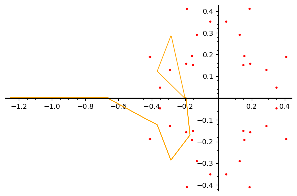

```python
path = surface.paths[30]

(
    list_plot([[z.real(), z.imag()] for z in surface.critical_values], color="red") +
    list_plot([[z.real(), z.imag()] for z in path], True, color="orange")
)
```

We additionally order the loops in a way that makes their composition the loop around $\infty$:

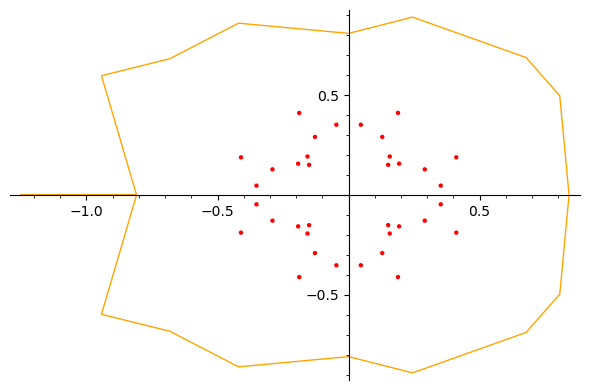

```python
from lefschetz_family.util import Util

paths = surface.paths
pathtot = []
for p in paths:
    pathtot= pathtot+p
pathtot = Util.simplify_path(pathtot)
pathtot

(
    list_plot([[z.real(), z.imag()] for z in surface.critical_values], color="red") +
    list_plot([[z.real(), z.imag()] for z in pathtot], True, color="orange")
)
```

Then for each of these loops $\ell$ we compute the matrix of the action of monodromy along $\ell$ in $H_{n-1}(Y_b)$ (given in the basis of homology of the period matrix).

```python
surface.fiber.cohomology
```

```
[Z, Y, X, Z^5, Y*Z^4, X*Z^4]
```

The fibre is a quartic curve, it has genus $3$.

```python
surface.fiber.homology
```

```
[(1, 0, 0, 0, 0, 0),
 (0, 1, 0, 0, 0, 0),
 (0, 0, 1, 0, 0, 0),
 (0, 0, 0, 1, 0, 0),
 (0, 0, 0, 0, 1, 0),
 (0, 0, 0, 0, 0, 1)]
```

```python
surface.family.pol
```

```
(16*X^4 + 96*X^3*Y + 216*X^2*Y^2 + 216*X*Y^3 + 81*Y^4 + 32*X^3*Z + 144*X^2*Y*Z + 216*X*Y^2*Z + 108*Y^3*Z + 24*X^2*Z^2 + 72*X*Y*Z^2 + 54*Y^2*Z^2 + 8*X*Z^3 + 12*Y*Z^3 + Z^4)*t^4 + X^4 + Y^4 + Z^4
```

```python
surface._restrict_form(surface.cohomology[0])
```

```
2*X + 3*Y + Z
```

To compute the monodromy matrices, we integrate the Picard-Fuchs operator of the holomorphic form. It has order $6$ and degree $129$.

```python
surface.picard_fuchs_equation(0).degree(), surface.picard_fuchs_equation(0).order()
```

```
INFO:lefschetz_family.hypersurface:[2] Computing Picard-Fuchs equations of 21 forms in dimension 2
INFO:lefschetz_family.hypersurface:[2] Operator [1/21] has order 6 and degree 129 for form with numerator of degree 0
INFO:lefschetz_family.hypersurface:[2] Operator [2/21] has order 6 and degree 152 for form with numerator of degree 4
INFO:lefschetz_family.hypersurface:[2] Operator [3/21] has order 6 and degree 152 for form with numerator of degree 4
INFO:lefschetz_family.hypersurface:[2] Operator [4/21] has order 6 and degree 152 for form with numerator of degree 4
INFO:lefschetz_family.hypersurface:[2] Operator [5/21] has order 6 and degree 236 for form with numerator of degree 4
INFO:lefschetz_family.hypersurface:[2] Operator [6/21] has order 6 and degree 236 for form with numerator of degree 4
INFO:lefschetz_family.hypersurface:[2] Operator [7/21] has order 6 and degree 236 for form with numerator of degree 4
INFO:lefschetz_family.hypersurface:[2] Operator [8/21] has order 6 and degree 245 for form with numerator of degree 4
INFO:lefschetz_family.hypersurface:[2] Operator [9/21] has order 6 and degree 245 for form with numerator of degree 4
INFO:lefschetz_family.hypersurface:[2] Operator [10/21] has order 6 and degree 245 for form with numerator of degree 4
INFO:lefschetz_family.hypersurface:[2] Operator [11/21] has order 6 and degree 245 for form with numerator of degree 4
INFO:lefschetz_family.hypersurface:[2] Operator [12/21] has order 6 and degree 245 for form with numerator of degree 4
INFO:lefschetz_family.hypersurface:[2] Operator [13/21] has order 6 and degree 245 for form with numerator of degree 4
INFO:lefschetz_family.hypersurface:[2] Operator [14/21] has order 6 and degree 245 for form with numerator of degree 4
INFO:lefschetz_family.hypersurface:[2] Operator [15/21] has order 6 and degree 254 for form with numerator of degree 4
INFO:lefschetz_family.hypersurface:[2] Operator [16/21] has order 6 and degree 254 for form with numerator of degree 4
INFO:lefschetz_family.hypersurface:[2] Operator [17/21] has order 6 and degree 254 for form with numerator of degree 4
INFO:lefschetz_family.hypersurface:[2] Operator [18/21] has order 6 and degree 254 for form with numerator of degree 4
INFO:lefschetz_family.hypersurface:[2] Operator [19/21] has order 6 and degree 254 for form with numerator of degree 4
INFO:lefschetz_family.hypersurface:[2] Operator [20/21] has order 6 and degree 254 for form with numerator of degree 4
INFO:lefschetz_family.hypersurface:[2] Operator [21/21] has order 6 and degree 488 for form with numerator of degree 8
```

```
(129, 6)
```

```python
surface.monodromy_matrices
```

```
INFO:lefschetz_family.hypersurface:[2] Computing numerical transition matrices of operator of order 7 and degree 129 (91 edges total).
INFO:lefschetz_family.hypersurface:[2] Integration finished -- total time: 00:09:59.
```

```
[
[ 1  0  0  0  0  0]  [ 2  1  0  1  0  0]  [ 1  0  1  1  1  2]
[ 0  1  0  0  0  0]  [-1  0  0 -1  0  0]  [ 0  1 -1 -1 -1 -2]
[ 0  0  2  1  1  1]  [ 0  0  1  0  0  0]  [ 0  0  2  1  1  2]
[ 0  0  0  1  0  0]  [ 0  0  0  1  0  0]  [ 0  0  0  1  0  0]
[ 0  0  0  0  1  0]  [ 0  0  0  0  1  0]  [ 0  0  1  1  2  2]
[ 0  0 -1 -1 -1  0], [ 0  0  0  0  0  1], [ 0  0 -1 -1 -1 -1],

[ 2  2  0  0  0 -1]  [1 1 1 1 1 1]  [ 1  0  0  0  0  0]
[ 0  1  0  0  0  0]  [0 1 0 0 0 0]  [ 0  1  0 -1 -1 -1]
[-2 -4  1  0  0  2]  [0 0 1 0 0 0]  [ 0  0  1  1  1  1]
[ 0  0  0  1  0  0]  [0 0 0 1 0 0]  [ 0  0  0  2  1  1]
[ 0  0  0  0  1  0]  [0 0 0 0 1 0]  [ 0  0  0  0  1  0]
[ 1  2  0  0  0  0], [0 0 0 0 0 1], [ 0  0  0 -1 -1  0],

[ 1  0  0  0 -1  0]  [ 1  0  0  0  0  0]  [ 1  0  0  0  0  0]
[ 0  1  0  0  0  0]  [ 0  1  0  0 -1 -1]  [-1  1  0  0  0  0]
[ 0  0  1  0  0  0]  [ 0  0  1  0  0  0]  [ 0  0  1  0  0  0]
[ 0  0  0  1  1  0]  [ 0  0  0  1  1  1]  [ 0  0  0  1  0  0]
[ 0  0  0  0  1  0]  [ 0  0  0  0  2  1]  [ 1  0  0  0  1  0]
[ 0  0  0  0 -1  1], [ 0  0  0  0 -1  0], [-1  0  0  0  0  1],

[ 2  1  0  1  0  0]  [ 1  0  0  0  0  0]  [ 2  1  0  1  1  1]
[-1  0  0 -1  0  0]  [-1  1  1  1  1  1]  [-2 -1  0 -2 -2 -2]
[ 0  0  1  0  0  0]  [-1  0  2  1  1  1]  [ 0  0  1  0  0  0]
[ 0  0  0  1  0  0]  [ 0  0  0  1  0  0]  [ 1  1  0  2  1  1]
[ 0  0  0  0  1  0]  [ 1  0 -1 -1  0 -1]  [ 1  1  0  1  2  1]
[ 0  0  0  0  0  1], [ 0  0  0  0  0  1], [-1 -1  0 -1 -1  0],

[ 3  2 -1  0  0 -1]  [ 1  0  0  0  0  0]  [ 2  1  0  0  1  1]
[-4 -3  2  0  0  2]  [-1  0  0  0 -1  0]  [-2 -1  0  0 -2 -2]
[-4 -4  3  0  0  2]  [-1 -1  1  0 -1  0]  [-1 -1  1  0 -1 -1]
[ 2  2 -1  1  0 -1]  [ 1  1  0  1  1  0]  [ 1  1  0  1  1  1]
[ 2  2 -1  0  1 -1]  [ 1  1  0  0  2  0]  [ 2  2  0  0  3  2]
[ 0  0  0  0  0  1], [-1 -1  0  0 -1  1], [-1 -1  0  0 -1  0],

[ 3  1  0  0  0  0]  [ 2  1  0  0  0  0]  [ 2  1  0  0  0  0]
[-4 -1  0  0  0  0]  [-1  0  0  0  0  0]  [-1  0  0  0  0  0]
[-2 -1  1  0  0  0]  [-1 -1  1  0  0  0]  [-1 -1  1  0  0  0]
[ 0  0  0  1  0  0]  [ 0  0  0  1  0  0]  [ 0  0  0  1  0  0]
```

[output cut: 30 more lines]

```

[ 3  4  2  2  2  2]  [ 1  1  0  0  0  0]  [ 2  1  0  0 -1 -1]
[-1 -1 -1 -1 -1 -1]  [ 0  1  0  0  0  0]  [ 0  1  0  0  0  0]
[-1 -2  0 -1 -1 -1]  [ 0 -1  1  0  0  0]  [-1 -1  1  0  1  1]
[ 0  0  0  1  0  0]  [ 0  0  0  1  0  0]  [-1 -1  0  1  1  1]
[ 1  2  1  1  2  1]  [ 0  0  0  0  1  0]  [ 0  0  0  0  1  0]
[ 0  0  0  0  0  1], [ 0  1  0  0  0  1], [ 1  1  0  0 -1  0],

[ 1  0  0  0  0  0]  [ 1  0  1  0  0  1]  [ 1  0  0  0  0  0]
[ 0  2  0  0  0 -1]  [ 0  1  0  0  0  0]  [ 0  1  0  0  0  0]
[ 0 -1  1  0  0  1]  [ 0  0  1  0  0  0]  [ 0 -1  1  0 -1  0]
[ 0  0  0  1  0  0]  [ 0  0 -1  1  0 -1]  [ 0  1  0  1  1  0]
[ 0 -1  0  0  1  1]  [ 0  0  1  0  1  1]  [ 0  0  0  0  1  0]
[ 0  1  0  0  0  0], [ 0  0  0  0  0  1], [ 0  0  0  0  0  1]
]
```

From then on we can easily recover everything we need

This is the transpose of the $36\times 6$ matrix of the boundary map $\delta : H_2(Y_+, Y_b)\to H_1(Y_b)$.

```python
matrix(surface.vanishing_cycles).transpose()
```

```
[ 0  1  1  1  1  0  1  0  0  1  0  1  1  0  1  1  1  1  1  1  0  1 -2 -3 -2 -3 -2 -2  0  1 -2  1  1  0  1  0]
[ 0 -1 -1  0  0  1  0  1  1 -1  1 -2 -2  1 -2 -2 -1 -1 -1 -1  0 -1  1  2  1  2  1  1  0  0  1  0  0  1  0  0]
[ 1  0  1 -2  0 -1  0  0  0  0  1  0 -2  1 -1 -1 -1 -1 -1 -1  1  0  3  2  1  2  2  2  1 -2  1 -1 -1 -1  0  1]
[ 0  0  0  0  0 -1 -1 -1  0  0  0  1  1 -1  1  0  0  0  0  0  0  0  1  0  1  1  0  1  0 -1  0  0 -1  0 -1 -1]
[ 0  0  1  0  0  0  0 -1 -1  0 -1  1  1 -1  2  2  1  1  1  1  0  0 -2 -2 -2 -2 -1 -1  0  1 -1  0  0 -1  1  0]
[-1  0 -1  1  0  1  1  1  1  0  0 -1  0  1 -1 -1  0  0  0  0 -1  0 -1  0  0 -1 -1 -1 -1  1  0  1  1  1  0  0]
```

The lines of the following $6\times 36$ matrix are the coefficients of the extensions around infinity in the basis of thimbles. They generate the image of the extension map $\tau^2_\infty:H_{n-1}(Y_b)\to H_{n}(Y_+)$. These extensions are trivial in $H_2(Y)$, but not in $H_2(Y_+)$. We check that they lie in $\ker\delta$.

```python
matrix(surface.infinity_loops)
```

```
[ 0  1  0  0 -1  0  0  0 -1 -1  0 -1  0  0  0 -1  1  1  1  1 -1  0  1  0  0  0  0  1  1  0 -1  0  1  0  0  0]
[ 0  1  0  1 -1 -1  0  0 -1  0 -1  0 -1  0 -1 -1  1  1  1  1 -1  0  0  0  0 -1  1  2  1  0  0  0  0  1  1 -1]
[ 1  0  0  1  0  0  0  0 -1  0 -1  0  0 -1 -1 -1  0  0  0  0 -1  0  0  0  0 -1  0  1  0 -1  0  0  0  0  1  0]
[ 1  1  0  0  0  0  0  1 -1  0 -1 -1  0  0  0  0  0  0  0  0 -1 -1  0  0  0  0 -1  1  0 -1 -1  0  0  0  0  0]
[ 1  0  0  1  0 -1 -1  1  0  1 -1  0  0  0 -1  0  0  0  0  0 -1  0  0  1 -1 -1  0  1  0  0  0  0 -1  0  1 -1]
[ 1  0  1  0  1  0 -1  1 -1  0  0 -1  1 -1 -1  0  0  0  0  0 -1  0  0  1  0  0 -1  0 -1 -1  0  1  0 -1  1  0]
```

```python
matrix(surface.infinity_loops)*matrix(surface.vanishing_cycles)
```

```
[0 0 0 0 0 0]
[0 0 0 0 0 0]
[0 0 0 0 0 0]
[0 0 0 0 0 0]
[0 0 0 0 0 0]
[0 0 0 0 0 0]
```

Cycles representing a basis of the $\frac{\ker\delta}{\operatorname{im}\tau_\infty^2}$ term in the description of $H_n(Y)$ in Theorem 1 can be obtained by finding a complement of $\operatorname{im}\tau_\infty^2$ in $\ker\delta$:

```python
print(matrix(surface.extensions))
```

```
INFO:lefschetz_family.hypersurface:[2] Reconstructed homology from monodromy -- total time: 00:00:00.
```

```
[ 1  0  0  0  0  0  0  0  0  0  0  0  0  0  0  0  0  0  0  0  0  0  0  0  0  0  0  0  0  0  1  1  1 -1  0 -1]
[ 0  1  0  0  0  0  0  0  0  0  0  0  0  0  0  0  0  0  0  0  0  0  0  0  0  0  0  0  0  0  1  0  0  0  1 -1]
[ 0  0  1  0  0  0  0  0  0  0  0  0  0  0  0  0  0  0  0  0  0  0  0  0  0  0  0  0  0  0  1  0  1  0  0 -1]
[ 0  0  0  1  0  0  0  0  0  0  0  0  0  0  0  0  0  0  0  0  0  0  0  0  0  0  0  0  0  0  0  0 -1  0  0  1]
[ 0  0  0  0  1  0  0  0  0  0  0  0  0  0  0  0  0  0  0  0  0  0  0  0  0  0  0  0  0  0  1  0  1 -1  0 -1]
[ 0  0  0  0  0  1  0  0  0  0  0  0  0  0  0  0  0  0  0  0  0  0  0  0  0  0  0  0  0  0 -1  0 -1  0 -1  1]
[ 0  0  0  0  0  0  1  0  0  0  0  0  0  0  0  0  0  0  0  0  0  0  0  0  0  0  0  0  0  0  0 -1  0  0  0 -1]
[ 0  0  0  0  0  0  0  1  0  0  0  0  0  0  0  0  0  0  0  0  0  0  0  0  0  0  0  0  0  0  0  0  0 -1  0 -1]
[ 0  0  0  0  0  0  0  0  1  0  0  0  0  0  0  0  0  0  0  0  0  0  0  0  0  0  0  0  0  0  0 -1  1 -1  0 -1]
[ 0  0  0  0  0  0  0  0  0  1  0  0  0  0  0  0  0  0  0  0  0  0  0  0  0  0  0  0  0  0  1  0  0  0  1 -1]
[ 0  0  0  0  0  0  0  0  0  0  1  0  0  0  0  0  0  0  0  0  0  0  0  0  0  0  0  0  0  0  1  0  2 -2  0 -2]
[ 0  0  0  0  0  0  0  0  0  0  0  1  0  0  0  0  0  0  0  0  0  0  0  0  0  0  0  0  0  0  1  0  0  1  1  0]
[ 0  0  0  0  0  0  0  0  0  0  0  0  1  0  0  0  0  0  0  0  0  0  0  0  0  0  0  0  0  0  0  0 -2  2  1  2]
[ 0  0  0  0  0  0  0  0  0  0  0  0  0  1  0  0  0  0  0  0  0  0  0  0  0  0  0  0  0  0  0 -1  1 -1  0 -2]
[ 0  0  0  0  0  0  0  0  0  0  0  0  0  0  1  0  0  0  0  0  0  0  0  0  0  0  0  0  0  0  0  0 -1  2  0  2]
[ 0  0  0  0  0  0  0  0  0  0  0  0  0  0  0  1  0  0  0  0  0  0  0  0  0  0  0  0  0  0  0  1 -2  2  0  2]
[ 0  0  0  0  0  0  0  0  0  0  0  0  0  0  0  0  1  0  0  0  0  0  0  0  0  0  0  0  0  0  0  0 -1  1  0  1]
[ 0  0  0  0  0  0  0  0  0  0  0  0  0  0  0  0  0  1  0  0  0  0  0  0  0  0  0  0  0  0  0  0 -1  1  0  1]
[ 0  0  0  0  0  0  0  0  0  0  0  0  0  0  0  0  0  0  1  0  0  0  0  0  0  0  0  0  0  0  0  0 -1  1  0  1]
[ 0  0  0  0  0  0  0  0  0  0  0  0  0  0  0  0  0  0  0  1  0  0  0  0  0  0  0  0  0  0  0  0 -1  1  0  1]
[ 0  0  0  0  0  0  0  0  0  0  0  0  0  0  0  0  0  0  0  0  1  0  0  0  0  0  0  0  0  0  1  1  1 -1  0 -1]
[ 0  0  0  0  0  0  0  0  0  0  0  0  0  0  0  0  0  0  0  0  0  1  0  0  0  0  0  0  0  0  1  0  0  0  1 -1]
[ 0  0  0  0  0  0  0  0  0  0  0  0  0  0  0  0  0  0  0  0  0  0  1  0  0  0  0  0  0  0  1  0  3 -2  1 -3]
[ 0  0  0  0  0  0  0  0  0  0  0  0  0  0  0  0  0  0  0  0  0  0  0  0  1  0  0  0  0  0  0  0  1 -1  1 -1]
```

```python
for i, c in enumerate(surface.extensions[1]):
    if c!=0:
        print(i+1," : ", c)
```

```
2  :  1
31  :  1
35  :  1
36  :  -1
```

```python
show(surface.holomorphic_periods_modification.transpose())
```

\[\newcommand{\Bold}[1]{\mathbf{#1}}\left(\begin{array}{r} \verb|[+/-|\verb| |\verb|1.58e-265]|\verb| |\verb|+|\verb| |\verb|[+/-|\verb| |\verb|1.58e-265]*I| \\ \verb|[+/-|\verb| |\verb|1.59e-265]|\verb| |\verb|+|\verb| |\verb|[-1.718796454505093206872523944952639299475214112954790224068621…|\verb| |\verb|+/-|\verb| |\verb|4.15e-265]*I| \\ \verb|[+/-|\verb| |\verb|2.83e-260]|\verb| |\verb|+|\verb| |\verb|[-1.718796454505093206872523944952639299475214112954790224068621…|\verb| |\verb|+/-|\verb| |\verb|4.67e-260]*I| \\ \verb|[1.718796454505093206872523944952639299475214112954790224068621…|\verb| |\verb|+/-|\verb| |\verb|1.50e-268]|\verb| |\verb|+|\verb| |\verb|[+/-|\verb| |\verb|7.64e-269]*I| \\ \verb|[+/-|\verb| |\verb|1.58e-265]|\verb| |\verb|+|\verb| |\verb|[+/-|\verb| |\verb|1.58e-265]*I| \\ \verb|[+/-|\verb| |\verb|1.58e-265]|\verb| |\verb|+|\verb| |\verb|[1.718796454505093206872523944952639299475214112954790224068621…|\verb| |\verb|+/-|\verb| |\verb|4.14e-265]*I| \\ \verb|[+/-|\verb| |\verb|5.01e-263]|\verb| |\verb|+|\verb| |\verb|[+/-|\verb| |\verb|5.01e-263]*I| \\ \verb|[-1.718796454505093206872523944952639299475214112954790224068621…|\verb| |\verb|+/-|\verb| |\verb|3.23e-265]|\verb| |\verb|+|\verb| |\verb|[1.718796454505093206872523944952639299475214112954790224068621…|\verb| |\verb|+/-|\verb| |\verb|3.23e-265]*I| \\ \verb|[-1.718796454505093206872523944952639299475214112954790224068621…|\verb| |\verb|+/-|\verb| |\verb|5.63e-264]|\verb| |\verb|+|\verb| |\verb|[1.718796454505093206872523944952639299475214112954790224068621…|\verb| |\verb|+/-|\verb| |\verb|5.63e-264]*I| \\ \verb|[1.718796454505093206872523944952639299475214112954790224068621…|\verb| |\verb|+/-|\verb| |\verb|8.83e-250]|\verb| |\verb|+|\verb| |\verb|[-1.718796454505093206872523944952639299475214112954790224068621…|\verb| |\verb|+/-|\verb| |\verb|8.83e-250]*I| \\ \verb|[-3.437592909010186413745047889905278598950428225909580448137243…|\verb| |\verb|+/-|\verb| |\verb|9.19e-257]|\verb| |\verb|+|\verb| |\verb|[1.718796454505093206872523944952639299475214112954790224068621…|\verb| |\verb|+/-|\verb| |\verb|7.87e-257]*I| \\ \verb|[3.437592909010186413745047889905278598950428225909580448137243…|\verb| |\verb|+/-|\verb| |\verb|7.87e-261]|\verb| |\verb|+|\verb| |\verb|[-3.437592909010186413745047889905278598950428225909580448137243…|\verb| |\verb|+/-|\verb| |\verb|7.87e-261]*I| \\ \verb|[6.875185818020372827490095779810557197900856451819160896274487…|\verb| |\verb|+/-|\verb| |\verb|5.82e-255]|\verb| |\verb|+|\verb| |\verb|[-1.718796454505093206872523944952639299475214112954790224068621…|\verb| |\verb|+/-|\verb| |\verb|8.24e-255]*I| \\ \verb|[-3.437592909010186413745047889905278598950428225909580448137243…|\verb| |\verb|+/-|\verb| |\verb|7.28e-254]|\verb| |\verb|+|\verb| |\verb|[1.718796454505093206872523944952639299475214112954790224068621…|\verb| |\verb|+/-|\verb| |\verb|8.52e-254]*I| \\ \verb|[6.875185818020372827490095779810557197900856451819160896274487…|\verb| |\verb|+/-|\verb| |\ve…

```python
surface.holomorphic_periods_modification.transpose()[1,0]
```

```
[+/- 1.59e-265] + [-1.718796454505093206872523944952639299475214112954790224068621… +/- 4.15e-265]*I
```

```python
end=time.time()
print("Notebook computed in %s"%time.strftime("%H:%M:%S",time.gmtime(end-begin)))
```

```
Notebook computed in 00:17:27
```